# Wreck project

On ne dépasse jamais les 25% de cas proches à 500€ prêt pour un modèle donné représenté au moins 100 fois dans l’historique des réparations sur 2 ans.

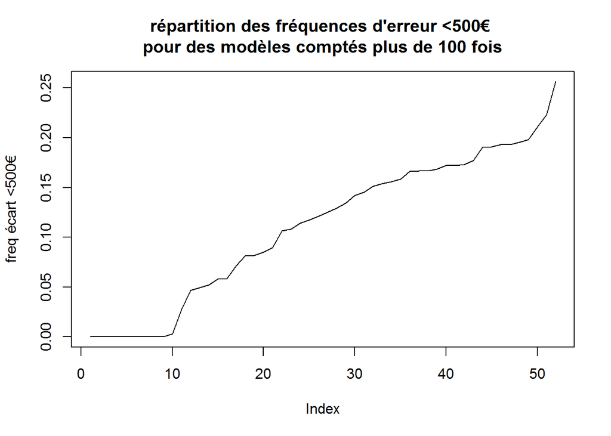

Essayons de faire de même pour la valeur modélisée.

On part d’une meilleure performance puisque dans 32% des cas l’écart entre VRADE et valeur prédite est inférieur à 500€.

Le principal facteur de discrimination est le modèle du véhicule. Ceci n’est pas surprenant d’autant que le nombre de modalités permet un affinage important suivant cette variable.

```
##    Min. 1st Qu.  Median    Mean 3rd Qu.    Max.
##  0.0000  0.0000  0.0000  0.3217  1.0000  1.0000
```

```
##      1        1.2464          1.2913     0.0100    0.0004
##      2        1.2452          1.2903     0.0100    0.0004
##      3        1.2441          1.2892     0.0100    0.0004
##      4        1.2431          1.2882     0.0100    0.0004
##      5        1.2420          1.2872     0.0100    0.0004
##      6        1.2410          1.2863     0.0100    0.0004
##      7        1.2400          1.2854     0.0100    0.0004
##      8        1.2390          1.2845     0.0100    0.0003
##      9        1.2379          1.2834     0.0100    0.0004
##     10        1.2370          1.2826     0.0100    0.0003
##     20        1.2280          1.2743     0.0100    0.0003
##     40        1.2134          1.2610     0.0100    0.0002
##     60        1.2025          1.2515     0.0100    0.0001
##     80        1.1940          1.2446     0.0100    0.0000
##    100        1.1873          1.2397     0.0100    0.0000
##    120        1.1817          1.2357     0.0100    0.0000
##    140        1.1773          1.2326     0.0100   -0.0000
##    150        1.1753          1.2313     0.0100   -0.0000
```

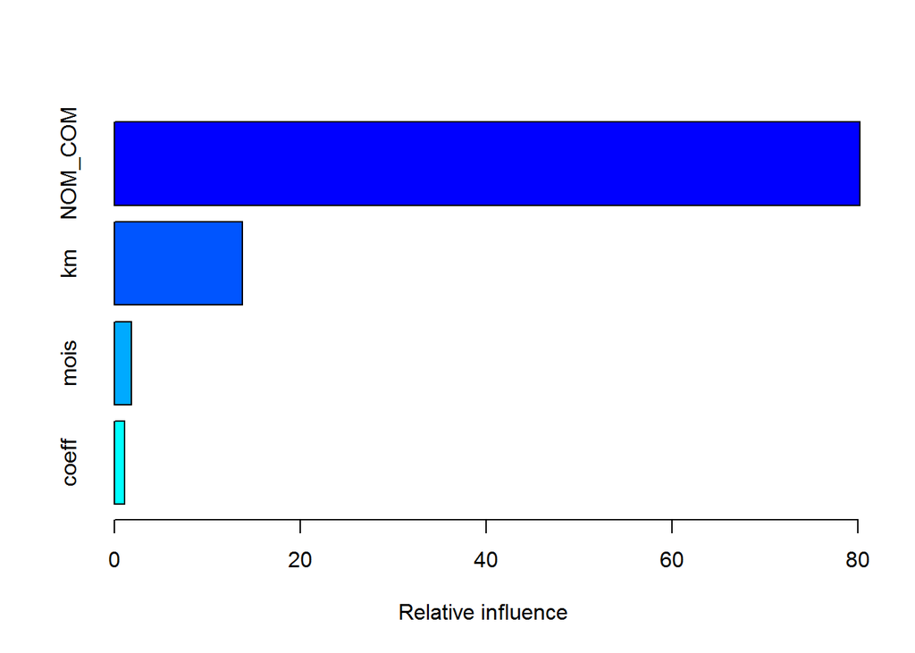

```
##                           var     rel.inf
## NOM_COM               NOM_COM 80.19866341
## km                         km 13.77006260
## mois                     mois  1.83342740
## coeff                   coeff  1.07190153
## table                   table  0.99175397
## CARROSS               CARROSS  0.53361311
## diffkm                 diffkm  0.44235067
## iiactu                 iiactu  0.29719068
## DIR_ASS               DIR_ASS  0.19341437
## ENERGIE               ENERGIE  0.13616536
## EMISSION_CO2     EMISSION_CO2  0.13574440
## PRIXACT               PRIXACT  0.10178123
## PUIS_REE             PUIS_REE  0.10136179
## ratiokm               ratiokm  0.06554438
## VIT_MAXI             VIT_MAXI  0.05371498
## BOIT_VIT             BOIT_VIT  0.04431687
## pmvkm                   pmvkm  0.02899326
## CYLINDRE             CYLINDRE  0.00000000
## GENRE                   GENRE  0.00000000
## FREIN                   FREIN  0.00000000
## CTRL_DYN_STAB   CTRL_DYN_STAB  0.00000000
## SERILIM               SERILIM  0.00000000
## NBRE_PTE             NBRE_PTE  0.00000000
## ctte                     ctte  0.00000000
## TRANS                   TRANS  0.00000000
## COUPLE_MOT_MAX COUPLE_MOT_MAX  0.00000000
```

De façon assez intuitive l’effet c.p. du kilométrage sur la fréquence prédite d’écarts <500€ croissant jusqu’à un niveau standard (200 000 km) et décroissant au délà.

```
## Using 150 trees...
```

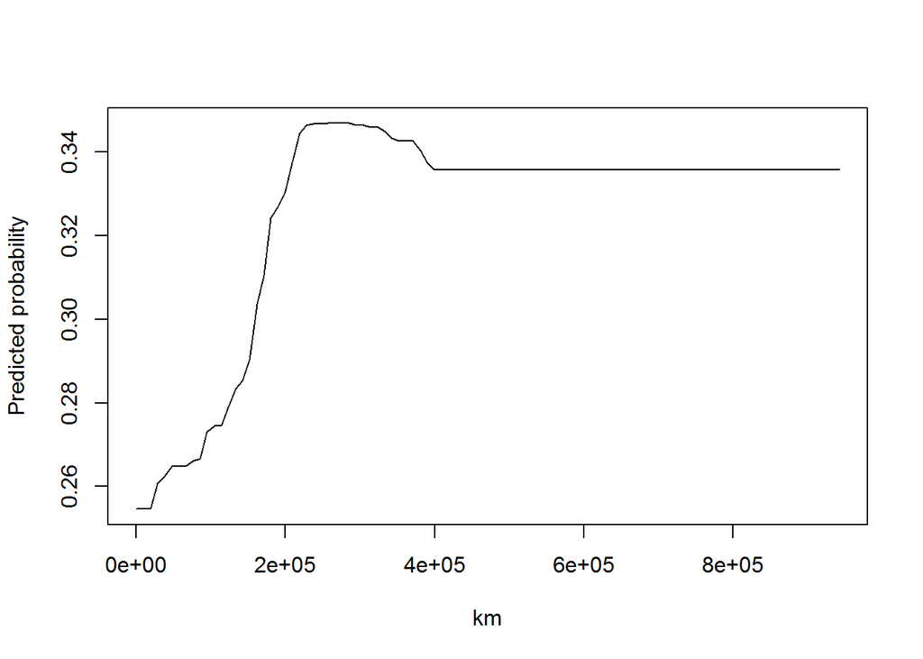

L’effet “modèle du véhicule” est remarquable, ceci dit le risque de sur-apprentissage est très important, certains modèles peuvent être présents une seule fois d’où un overfitting immédiat et une prédiction à 0 ou 1.

C’est ce qu’illustre le second graphe. Dans 99% la probabilité prédite d’un écart <500€ ne dépasse pas 50%.

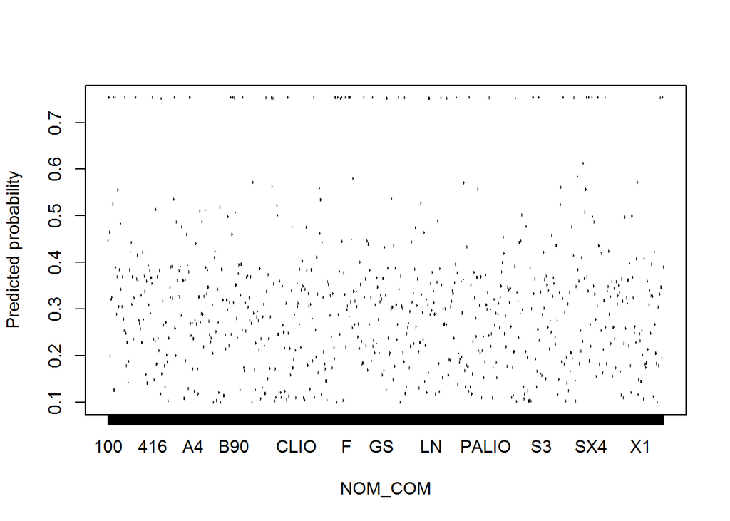

```
## Using 150 trees...
```

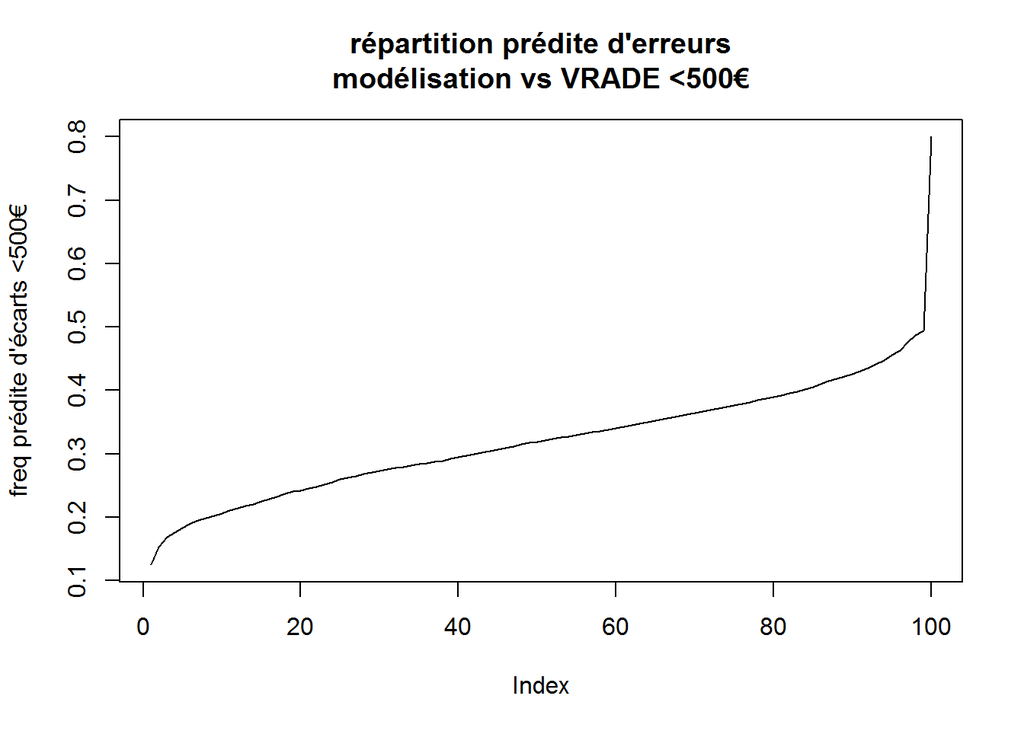

Tout comme pour les BT, on propose, pour les modèles de véhicules présents plus de 100 fois dans l’historique des réparations, de calculer (probabilité réelle) la fréquence d’écarts inférieurs à 500€.

On fait deux fois mieux qu’avec le bilan technique mais ça reste largement insuffisant.

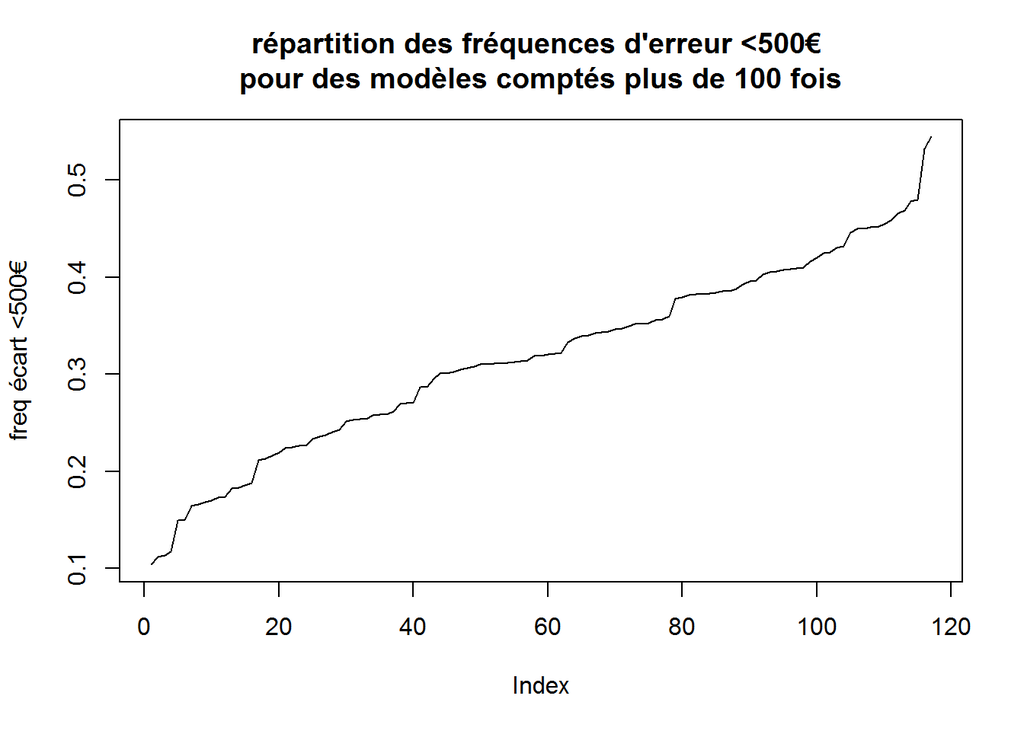

Dans la compréhension des erreurs du modèle on décide de mesurer la variabilité de la VRADE pour chaque modèle présent plus de 20 fois (sinon difficile d’estimer).

Les écart-types relatifs valent entre 32% et 114%, ce qui est énorme.

Cette dispersion s’explique par les différences de valeur importantes entre deux modèles selon la finition.

Un exemple assez frappant est celui du Renault Espace IV. On compte 119 cas de VEI pour ce modèle en 24 mois. La VRADE moyenne associée est 4100€ et l’écart type vaut 3800€.

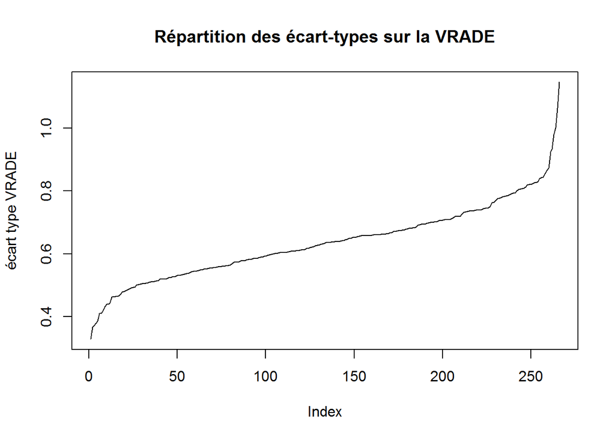